# Coursera Reproducible Research - Project 1

Alex Merg

1/26/20

## Introduction

It is now possible to collect a large amount of data about personal movement using activity monitoring devices such as a Fitbit, Nike Fuelband, or Jawbone Up. These type of devices are part of the “quantified self” movement – a group of enthusiasts who take measurements about themselves regularly to improve their health, to find patterns in their behavior, or because they are tech geeks. But these data remain under-utilized both because the raw data are hard to obtain and there is a lack of statistical methods and software for processing and interpreting the data.

This assignment makes use of data from a personal activity monitoring device. This device collects data at 5 minute intervals through out the day. The data consists of two months of data from an anonymous individual collected during the months of October and November, 2012 and include the number of steps taken in 5 minute intervals each day.

The data for this assignment can be downloaded [here](https://d396qusza40orc.cloudfront.net/repdata%2Fdata%2Factivity.zip).

The variables included in this dataset are:

- **steps**: Number of steps taking in a 5-minute interval (missing values are coded as NA)
- **date**: The date on which the measurement was taken in YYYY-MM-DD format
- **interval**: Identifier for the 5-minute interval in which measurement was taken

The dataset is stored in a comma-separated-value (CSV) file and there are a total of 17,568 observations in this dataset.

### Setting Up Environment

```r
knitr::opts_chunk$set(echo = TRUE)
setwd("~/Data Science/Coursera/Reproducible Research")
library(ggplot2)
library(dplyr)
```

## Tasks

### 1. Code for reading in the dataset and/or processing the data

```r
act_data <- read.csv("activity.csv")
Activity <- transform(act_data, date = as.Date(date))
```

### 2. Histogram of the total number of steps taken each day

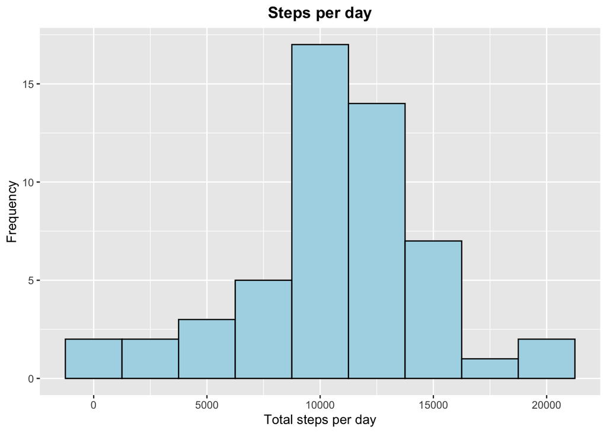

```r
TStepsByDay <- aggregate(steps ~ date, Activity, sum)
ggplot(data = TStepsByDay, aes(TStepsByDay$steps)) +
  geom_histogram(binwidth = 2500, fill = "lightblue", col = "black") +
  xlab('Total steps per day') +
  ylab('Frequency') +
  ggtitle('Steps per day') +
  theme(plot.title = element_text(face = "bold", hjust = 0.5))
```

### 3. Mean and median number of steps taken each day

```r
MeanSteps <- format(as.numeric(mean(TStepsByDay$steps)), nsmall = 2, big.mark = ",")
MedianSteps <- format(as.numeric(median(TStepsByDay$steps)), nsmall = 2, big.mark = ",")
```

**Mean**: 10,766.19

**Median**: 10,765.00

### 4. Time series plot of the average number of steps taken

[figure not shown]

```r
AvgSteps <- aggregate(steps ~ interval, Activity, mean)
ggplot(data = AvgSteps, aes(x = interval, y = steps)) +
  geom_line() +
  xlab('Interval') +
  ylab('Avg steps') +
  ggtitle('Average steps per 5-second interval') +
  theme(plot.title = element_text(face = "bold", hjust = 0.5))
```

### 5. The 5-minute interval that, on average, contains the maximum number of steps

```r
AvgSteps %>% filter(steps == max(steps))
```

```
##   interval    steps
## 1      835 206.1698
```

### 6. Code to describe and show a strategy for imputing missing data

**Find total number of NA’s**

```r
sum(is.na(Activity))
```

```
## [1] 2304
```

**Replace NA values with the mean results for 5-minute intervals**

```r
Activity2 <- Activity
NAvalues <- is.na(Activity2$steps)
AvgInterval <- tapply(Activity2$steps, Activity2$interval, mean, simplify = TRUE, na.rm = TRUE)
Activity2$steps[NAvalues] <- AvgInterval[as.character(Activity2$interval[NAvalues])]
```

**Check new dataset for NA’s**

```r
sum(is.na(Activity2))
```

```
## [1] 0
```

### 7. Histogram of the total number of steps taken each day after missing values are imputed

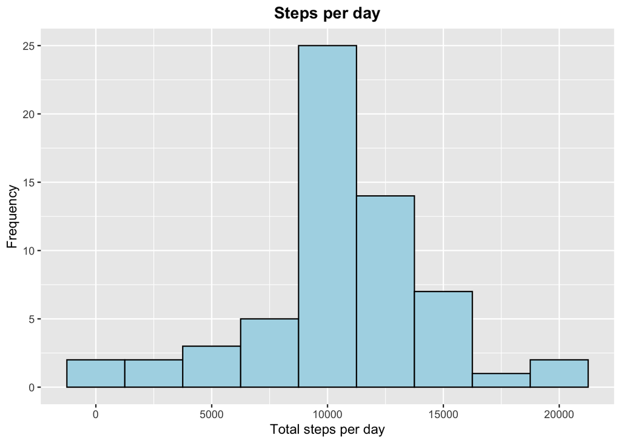

```r
TStepsByDay2 <- aggregate(steps ~ date, Activity2, FUN = sum, na.rm = TRUE)
ggplot(data = TStepsByDay2, aes(TStepsByDay2$steps)) +
  geom_histogram(binwidth = 2500, fill = "lightblue", col = "black") +
  xlab('Total steps per day') +
  ylab('Frequency') +
  ggtitle('Steps per day') +
  theme(plot.title = element_text(face = "bold", hjust = 0.5))
```

**Assess impact of imputing data**

```r
summary(TStepsByDay)
```

```
##       date                steps
##  Min.   :2012-10-02   Min.   :   41
##  1st Qu.:2012-10-16   1st Qu.: 8841
##  Median :2012-10-29   Median :10765
##  Mean   :2012-10-30   Mean   :10766
##  3rd Qu.:2012-11-16   3rd Qu.:13294
##  Max.   :2012-11-29   Max.   :21194
```

```r
summary(TStepsByDay2)
```

```
##       date                steps
##  Min.   :2012-10-01   Min.   :   41
##  1st Qu.:2012-10-16   1st Qu.: 9819
##  Median :2012-10-31   Median :10766
##  Mean   :2012-10-31   Mean   :10766
##  3rd Qu.:2012-11-15   3rd Qu.:12811
##  Max.   :2012-11-30   Max.   :21194
```

### 8. Panel plot comparing the average number of steps taken per 5-minute interval across weekdays and weekends

**Add variable denoting whether date is weekday or weekend**

```r
Activity2$date <- as.Date(Activity2$date)
Activity3 <-  Activity2 %>% mutate(DayType = ifelse(weekdays(Activity2$date)=="Saturday" | weekdays(Activity2$date) =="Sunday", "Weekend", "Weekday"))
```

**Aggregate data by interval and by type of date**

```r
AvgSteps2 <- aggregate(steps ~ interval + DayType, data = Activity3, FUN = mean)
```

**Plot data**

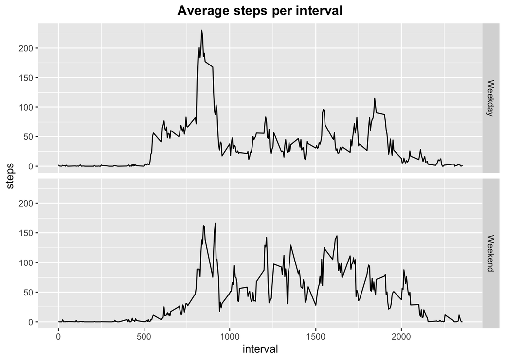

```r
ggplot(AvgSteps2, aes(interval, steps)) +
  facet_grid(DayType ~ .) +
  geom_line() +
  ggtitle("Average steps per interval") +
  theme(plot.title = element_text(face = "bold", hjust = 0.5))
```